# Lesson 9: Inference for One Mean; Sigma Known (Hypothesis Test)

Preparation

**Directions: Please fill in Part I as you study the Reading Assignment. Once you finish the reading, complete the questions on Part II. You may use your notes, the key, and the help videos. Be sure to take this completed assignment to your group meeting where you can ask and help answer questions on this assignment.**

## Problems

**Part I:** Use the information in the reading assignment to complete these questions.

1. Which hypothesis between the null and alternative hypothesis is the hypothesis of ‘no effect’ or ‘no difference’ or ‘status quo’ or is assumed to be true?
2. Does $H_a$ below represent a one-sided or two-sided alternative hypothesis?

$$H_o: \mu=0$$
$$H_a: \mu>0$$

3. Fill in the matrix below with the correct responses

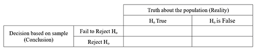

Truth Table

4. Define the level of significance in a hypothesis test? With which Greek letter is it denoted?
5. Write down the formula for computing the test statistic for the hypothesis test for a single mean when sigma is known.
6. Define the P-value. How is it used in a hypothesis test?
7. If the null hypothesis is rejected in a hypothesis test, what is concluded about the alternative hypothesis?
8. Think of a couple of examples where you have seen hypothesis testing in real life (open-ended).

**Part II**

9. The Graduate Management Admission Test (GMAT) is used as an admission criterion in many masters of business administration (MBA) programs. The scores on the GMAT in the past have a mean score of 529. The BYU professor feels now that the score has improved within the last couple of years.
   1. Determine the null and alternative hypotheses
   2. Suppose you got evidence that the null hypothesis should be rejected. However, in reality the mean score of students taking the exam is still 529. Was a Type I or Type II error committed?
   3. If the analysis was done at $\alpha$ = 0.01 level, what is the probability of committing a Type I Error?
   4. If we wanted to decrease the probability of making a Type II error, would we need to increase or decrease the level of significance?
10. A study by the National Association of Realtors reported in 2004 that second-home sales accounted for more than a third of residential real estate transactions. According to the report, the average age of a person buying a second home as an investment rental property was 47 years. Assuming the national standard deviation was 5, a real estate agent wants to determine if the average age of those buying investment property in his area is different than the national average. He randomly selects 15 of his clients who purchased an investment property and obtains the values – 27,49,56,45,49,35,55,50,46,48,38,58,51,56,38.
1. Design the Study. What is the population from which the realtor obtains his data. How did he sample this population? What is the research question?
2. Collect the data. Name at least one way the realtor could have randomly selected his sample.
3. Describe the data. Graph the data on a histogram. Sketch the histogram below or cut and paste your electronic copy. In a short paragraph describe the data by using at least five descriptive statistics.
4. Make inference:
   1. Check the requirements. Since there are only 15 pieces of data, what will you need to check?
   2. State the null and alternative hypothesis. (Is this a one or two-tailed test?)
   3. Let $\alpha= 0.05$
   4. Compute the test statistic. What is the formula to be used? (Recall our test statistic will be a z-score.) After writing down the general formula, input the numbers you will use. Show this work. Finally, use Excel or a calculator to compute your test statistics.
   5. Compute the P-value. First, sketch a standard normal curve; graph your test statistic along the horizontal axis. Shade the appropriate under the curve. Use the Normal Applet to compute the area under the curve. This area is the P-value.
   6. Compare the P-value to the level of significance (the $\alpha$-level). Do we reject the null hypothesis or fail to reject the null?
   7. State your conclusions in terms of the alternative hypothesis
5. Take Action: What action,if any, do you suggest the realtor to take based on your statistical conclusions?